# Week 5 Lab: Supervised Learning

[figure not shown]

This week's assignment will focus constructing and improving the performance of a KNN model.

## Dataset:

**Dataset:** bank-additional-full.csv (Provided in folder assign_wk5)

## Assignment Requirements

After reviewing the dataset's descriptive file (bank-additional-names.txt), define a research question to guide your analysis. Make sure your KNN Analysis addresses the following tasks:

- Cleanup the dataset as you deem appropriate. As always, defend your reasoning!!!
  - Missing values?
  - Column names
- Prepare the data for machine learning
  - A little EDA goeas a long way
  - Do you need to do anything about data types?
- KNN Analysis
  - What is your optimal K?
  - Evaluate the accuracy of your model
  - Discuss ways to improve the performance of your KNN model.
    - Notice the requirement states **ways** - meaning more than one!
    - Defend and backup your thoughts!!!!!!
- KNN Model Improvement
  - Implement one of those methods to improve your KNN model performance.
  - Did your second model perform better than the first?
- Conclusion/Summary
  - Compare and contrast your 2 models
  - Include numbers/graphs corresponding to your conclusions
  - Defend and backup your thoughts!!!!!!

# Deliverables:

Upload your Jupyter Notebook to the corresponding location in WorldClass.

**Note::** Make sure you have clearly indicated each assignment requirement within your notebook.

**Important:** Make sure you have clearly indicated each assignment requirement within your notebook. Also, I highly encourage you to use markdown text to create a notebook that integrates your analysis within your code. The narrative within your notebook will count for 50% of your total grade on this assignment.

```python
# %pip install notebook
```

```python
import warnings
warnings.filterwarnings("ignore")

from sklearn.preprocessing import LabelEncoder
import seaborn as sns
import matplotlib.pyplot as plt
from sklearn.model_selection import train_test_split
from sklearn.metrics import accuracy_score, classification_report, confusion_matrix
from sklearn.neighbors import KNeighborsClassifier
from sklearn.preprocessing import StandardScaler
import joblib
import pandas as pd

%matplotlib inline
sns.set_theme()
```

Lets load the bank dataset from csv to a dataframe and collect some descriptive statistics.

```python
bank_df = pd.read_csv('./assign_wk5/bank-additional-full.csv', delimiter=';')
bank_df
```

|  | age | job | marital | education | default | housing | loan | contact | month | day_of_week | ... | campaign | pdays | previous | poutcome | emp.var.rate | cons.price.idx | cons.conf.idx | euribor3m | nr.employed | y |
| --- | --- | --- | --- | --- | --- | --- | --- | --- | --- | --- | --- | --- | --- | --- | --- | --- | --- | --- | --- | --- | --- |
| 0 | 56 | housemaid | married | basic.4y | no | no | no | telephone | may | mon | ... | 1 | 999 | 0 | nonexistent | 1.1 | 93.994 | -36.4 | 4.857 | 5191.0 | no |
| 1 | 57 | services | married | high.school | unknown | no | no | telephone | may | mon | ... | 1 | 999 | 0 | nonexistent | 1.1 | 93.994 | -36.4 | 4.857 | 5191.0 | no |
| 2 | 37 | services | married | high.school | no | yes | no | telephone | may | mon | ... | 1 | 999 | 0 | nonexistent | 1.1 | 93.994 | -36.4 | 4.857 | 5191.0 | no |
| 3 | 40 | admin. | married | basic.6y | no | no | no | telephone | may | mon | ... | 1 | 999 | 0 | nonexistent | 1.1 | 93.994 | -36.4 | 4.857 | 5191.0 | no |
| 4 | 56 | services | married | high.school | no | no | yes | telephone | may | mon | ... | 1 | 999 | 0 | nonexistent | 1.1 | 93.994 | -36.4 | 4.857 | 5191.0 | no |
| ... | ... | ... | ... | ... | ... | ... | ... | ... | ... | ... | ... | ... | ... | ... | ... | ... | ... | ... | ... | ... | ... |
| 41183 | 73 | retired | married | professional.course | no | yes | no | cellular | nov | fri | ... | 1 | 999 | 0 | nonexistent | -1.1 | 94.767 | -50.8 | 1.028 | 4963.6 | yes |
| 41184 | 46 | blue-collar | married | professional.course | no | no | no | cellular | nov | fri | ... | 1 | 999 | 0 | nonexistent | -1.1 | 94.767 | -50.8 | 1.028 | 4963.6 | no |
| 41185 | 56 | retired | married | university.degree | no | yes | no | cellular | nov | fri | ... | 2 | 999 | 0 | nonexistent | -1.1 | 94.767 | -50.8 | 1.028 | 4963.6 | no |
| 41186 | 44 | technician | married | professional.course | no | no | no | cellular | nov | fri | ... | 1 | 999 | 0 | nonexistent | -1.1 | 94.767 | -50.8 | 1.028 | 4963.6 | yes |
| 41187 | 74 | retired | married | professional.course | no | yes | no | cellular | nov | fri | ... | 3 | 999 | 1 | failure | -1.1 | 94.767 | -50.8 | 1.028 | 4963.6 | no |

41188 rows × 21 columns

```python
bank_df.info()
```

```
<class 'pandas.core.frame.DataFrame'>
RangeIndex: 41188 entries, 0 to 41187
Data columns (total 21 columns):
 #   Column          Non-Null Count  Dtype
---  ------          --------------  -----
 0   age             41188 non-null  int64
 1   job             41188 non-null  object
 2   marital         41188 non-null  object
 3   education       41188 non-null  object
 4   default         41188 non-null  object
 5   housing         41188 non-null  object
 6   loan            41188 non-null  object
 7   contact         41188 non-null  object
 8   month           41188 non-null  object
 9   day_of_week     41188 non-null  object
 10  duration        41188 non-null  int64
 11  campaign        41188 non-null  int64
 12  pdays           41188 non-null  int64
 13  previous        41188 non-null  int64
 14  poutcome        41188 non-null  object
 15  emp.var.rate    41188 non-null  float64
 16  cons.price.idx  41188 non-null  float64
 17  cons.conf.idx   41188 non-null  float64
 18  euribor3m       41188 non-null  float64
 19  nr.employed     41188 non-null  float64
 20  y               41188 non-null  object
dtypes: float64(5), int64(5), object(11)
memory usage: 6.6+ MB
```

From the columns listed, it can be infered that each row represents a profile or representation of an individual based on financial or banking information.

The bank-additional-names.txt file states, `There are several missing values in some categorical attributes, all coded with the "unknown" label.`

Lets check if there are any `null values` and additionally check how many values are labeled with `unknown`.

```python
bank_df.isnull().sum()
```

```
age               0
job               0
marital           0
education         0
default           0
housing           0
loan              0
contact           0
month             0
day_of_week       0
duration          0
campaign          0
pdays             0
previous          0
poutcome          0
emp.var.rate      0
cons.price.idx    0
cons.conf.idx     0
euribor3m         0
nr.employed       0
y                 0
dtype: int64
```

There are 0 null values in the dataset.

Lets continue checking for `unknown` values.

```python
(bank_df == 'unknown').sum()
```

```
age                  0
job                330
marital             80
education         1731
default           8597
housing            990
loan               990
contact              0
month                0
day_of_week          0
duration             0
campaign             0
pdays                0
previous             0
poutcome             0
emp.var.rate         0
cons.price.idx       0
cons.conf.idx        0
euribor3m            0
nr.employed          0
y                    0
dtype: int64
```

There are only a few columns that contain 'unknown' values. Let's get a better understanding of the percentage of unknown values relative to the number of values in entire dataset.

```python
unknown_size = (bank_df == 'unknown').sum().sum()
bank_size = bank_df.size
print("The number of unknown values is:", unknown_size)
print("The total number of values in the bank dataset is:", bank_size)
print("Percent of values that are unknown: %", (unknown_size / bank_size * 100))
```

```
The number of unknown values is: 12718
The total number of values in the bank dataset is: 864948
Percent of values that are unknown: % 1.4703774099714664
```

1.5% seems insignificant so it might make sense to drop 'unknown' values.

Before proceeding with dropping unkown values, lets identify how many rows of the dataset have at least 1 unknown value.

```python
unknown_rows = (bank_df == 'unknown').any(axis=1).sum()
total_rows = len(bank_df)

print("The number of rows with at least one 'unknown' value is:", unknown_rows)
print("The total number of rows in the dataset is:", total_rows)

percentage_unknown_rows = (unknown_rows / total_rows) * 100
print(f"Percentage of rows with 'unknown' values: {percentage_unknown_rows:.2f}%")
```

```
The number of rows with at least one 'unknown' value is: 10700
The total number of rows in the dataset is: 41188
Percentage of rows with 'unknown' values: 25.98%
```

The number of rows in the dataset that contain at least 1 unkown value is almost `26%`. This is an high number of incomplete rows or individual profiles.

`Simply dropping 26% of the dataset is not a viable solution, regardless of how large the dataset is.`

For now, lets seperate the rows that contain null values and save both the cleaned portion and the uncleaned portion to csv's. We can decide how to impute the missing data values later on.

```python
bank_with_unknown = bank_df[bank_df.eq('unknown').any(axis=1)]
bank_with_unknown.to_csv('./assign_wk5/generated_data/bank_with_unknown_values.csv', index=False)
bank_with_unknown
```

|  | age | job | marital | education | default | housing | loan | contact | month | day_of_week | ... | campaign | pdays | previous | poutcome | emp.var.rate | cons.price.idx | cons.conf.idx | euribor3m | nr.employed | y |
| --- | --- | --- | --- | --- | --- | --- | --- | --- | --- | --- | --- | --- | --- | --- | --- | --- | --- | --- | --- | --- | --- |
| 1 | 57 | services | married | high.school | unknown | no | no | telephone | may | mon | ... | 1 | 999 | 0 | nonexistent | 1.1 | 93.994 | -36.4 | 4.857 | 5191.0 | no |
| 5 | 45 | services | married | basic.9y | unknown | no | no | telephone | may | mon | ... | 1 | 999 | 0 | nonexistent | 1.1 | 93.994 | -36.4 | 4.857 | 5191.0 | no |
| 7 | 41 | blue-collar | married | unknown | unknown | no | no | telephone | may | mon | ... | 1 | 999 | 0 | nonexistent | 1.1 | 93.994 | -36.4 | 4.857 | 5191.0 | no |
| 10 | 41 | blue-collar | married | unknown | unknown | no | no | telephone | may | mon | ... | 1 | 999 | 0 | nonexistent | 1.1 | 93.994 | -36.4 | 4.857 | 5191.0 | no |
| 15 | 54 | retired | married | basic.9y | unknown | yes | yes | telephone | may | mon | ... | 1 | 999 | 0 | nonexistent | 1.1 | 93.994 | -36.4 | 4.857 | 5191.0 | no |
| ... | ... | ... | ... | ... | ... | ... | ... | ... | ... | ... | ... | ... | ... | ... | ... | ... | ... | ... | ... | ... | ... |
| 41118 | 34 | technician | married | unknown | no | yes | no | cellular | nov | tue | ... | 2 | 999 | 2 | failure | -1.1 | 94.767 | -50.8 | 1.046 | 4963.6 | no |
| 41120 | 60 | admin. | married | unknown | no | no | no | cellular | nov | tue | ... | 2 | 999 | 0 | nonexistent | -1.1 | 94.767 | -50.8 | 1.046 | 4963.6 | no |
| 41122 | 34 | technician | married | unknown | no | no | no | cellular | nov | tue | ... | 3 | 999 | 0 | nonexistent | -1.1 | 94.767 | -50.8 | 1.046 | 4963.6 | yes |
| 41135 | 54 | technician | married | unknown | no | yes | no | cellular | nov | thu | ... | 1 | 999 | 1 | failure | -1.1 | 94.767 | -50.8 | 1.041 | 4963.6 | no |
| 41175 | 34 | student | single | unknown | no | yes | no | cellular | nov | thu | ... | 1 | 999 | 2 | failure | -1.1 | 94.767 | -50.8 | 1.031 | 4963.6 | no |

10700 rows × 21 columns

```python
bank_without_unknown = bank_df[~bank_df.eq('unknown').any(axis=1)]
bank_without_unknown.to_csv('./assign_wk5/generated_data/bank_without_unknown_values.csv', index=False)
bank_without_unknown
```

|  | age | job | marital | education | default | housing | loan | contact | month | day_of_week | ... | campaign | pdays | previous | poutcome | emp.var.rate | cons.price.idx | cons.conf.idx | euribor3m | nr.employed | y |
| --- | --- | --- | --- | --- | --- | --- | --- | --- | --- | --- | --- | --- | --- | --- | --- | --- | --- | --- | --- | --- | --- |
| 0 | 56 | housemaid | married | basic.4y | no | no | no | telephone | may | mon | ... | 1 | 999 | 0 | nonexistent | 1.1 | 93.994 | -36.4 | 4.857 | 5191.0 | no |
| 2 | 37 | services | married | high.school | no | yes | no | telephone | may | mon | ... | 1 | 999 | 0 | nonexistent | 1.1 | 93.994 | -36.4 | 4.857 | 5191.0 | no |
| 3 | 40 | admin. | married | basic.6y | no | no | no | telephone | may | mon | ... | 1 | 999 | 0 | nonexistent | 1.1 | 93.994 | -36.4 | 4.857 | 5191.0 | no |
| 4 | 56 | services | married | high.school | no | no | yes | telephone | may | mon | ... | 1 | 999 | 0 | nonexistent | 1.1 | 93.994 | -36.4 | 4.857 | 5191.0 | no |
| 6 | 59 | admin. | married | professional.course | no | no | no | telephone | may | mon | ... | 1 | 999 | 0 | nonexistent | 1.1 | 93.994 | -36.4 | 4.857 | 5191.0 | no |
| ... | ... | ... | ... | ... | ... | ... | ... | ... | ... | ... | ... | ... | ... | ... | ... | ... | ... | ... | ... | ... | ... |
| 41183 | 73 | retired | married | professional.course | no | yes | no | cellular | nov | fri | ... | 1 | 999 | 0 | nonexistent | -1.1 | 94.767 | -50.8 | 1.028 | 4963.6 | yes |
| 41184 | 46 | blue-collar | married | professional.course | no | no | no | cellular | nov | fri | ... | 1 | 999 | 0 | nonexistent | -1.1 | 94.767 | -50.8 | 1.028 | 4963.6 | no |
| 41185 | 56 | retired | married | university.degree | no | yes | no | cellular | nov | fri | ... | 2 | 999 | 0 | nonexistent | -1.1 | 94.767 | -50.8 | 1.028 | 4963.6 | no |
| 41186 | 44 | technician | married | professional.course | no | no | no | cellular | nov | fri | ... | 1 | 999 | 0 | nonexistent | -1.1 | 94.767 | -50.8 | 1.028 | 4963.6 | yes |
| 41187 | 74 | retired | married | professional.course | no | yes | no | cellular | nov | fri | ... | 3 | 999 | 1 | failure | -1.1 | 94.767 | -50.8 | 1.028 | 4963.6 | no |

30488 rows × 21 columns

```python
clean_df = pd.read_csv('./assign_wk5/generated_data/bank_without_unknown_values.csv')
clean_df
```

|  | age | job | marital | education | default | housing | loan | contact | month | day_of_week | ... | campaign | pdays | previous | poutcome | emp.var.rate | cons.price.idx | cons.conf.idx | euribor3m | nr.employed | y |
| --- | --- | --- | --- | --- | --- | --- | --- | --- | --- | --- | --- | --- | --- | --- | --- | --- | --- | --- | --- | --- | --- |
| 0 | 56 | housemaid | married | basic.4y | no | no | no | telephone | may | mon | ... | 1 | 999 | 0 | nonexistent | 1.1 | 93.994 | -36.4 | 4.857 | 5191.0 | no |
| 1 | 37 | services | married | high.school | no | yes | no | telephone | may | mon | ... | 1 | 999 | 0 | nonexistent | 1.1 | 93.994 | -36.4 | 4.857 | 5191.0 | no |
| 2 | 40 | admin. | married | basic.6y | no | no | no | telephone | may | mon | ... | 1 | 999 | 0 | nonexistent | 1.1 | 93.994 | -36.4 | 4.857 | 5191.0 | no |
| 3 | 56 | services | married | high.school | no | no | yes | telephone | may | mon | ... | 1 | 999 | 0 | nonexistent | 1.1 | 93.994 | -36.4 | 4.857 | 5191.0 | no |
| 4 | 59 | admin. | married | professional.course | no | no | no | telephone | may | mon | ... | 1 | 999 | 0 | nonexistent | 1.1 | 93.994 | -36.4 | 4.857 | 5191.0 | no |
| ... | ... | ... | ... | ... | ... | ... | ... | ... | ... | ... | ... | ... | ... | ... | ... | ... | ... | ... | ... | ... | ... |
| 30483 | 73 | retired | married | professional.course | no | yes | no | cellular | nov | fri | ... | 1 | 999 | 0 | nonexistent | -1.1 | 94.767 | -50.8 | 1.028 | 4963.6 | yes |
| 30484 | 46 | blue-collar | married | professional.course | no | no | no | cellular | nov | fri | ... | 1 | 999 | 0 | nonexistent | -1.1 | 94.767 | -50.8 | 1.028 | 4963.6 | no |
| 30485 | 56 | retired | married | university.degree | no | yes | no | cellular | nov | fri | ... | 2 | 999 | 0 | nonexistent | -1.1 | 94.767 | -50.8 | 1.028 | 4963.6 | no |
| 30486 | 44 | technician | married | professional.course | no | no | no | cellular | nov | fri | ... | 1 | 999 | 0 | nonexistent | -1.1 | 94.767 | -50.8 | 1.028 | 4963.6 | yes |
| 30487 | 74 | retired | married | professional.course | no | yes | no | cellular | nov | fri | ... | 3 | 999 | 1 | failure | -1.1 | 94.767 | -50.8 | 1.028 | 4963.6 | no |

30488 rows × 21 columns

Now that we have sperated the clean and unclean data, lets encode each column numerically.

```python
label_encoder = LabelEncoder()
bank_encoded = clean_df.copy()

for col in bank_encoded.select_dtypes(include=['object']).columns:
    bank_encoded[col] = label_encoder.fit_transform(bank_encoded[col])
```

After encoding the data, lets verify the data was encoded successfully by checking the number of unique values for each column before and after the encoding.

```python
for col in bank_encoded.columns:

    clean_col = clean_df[col].nunique()
    print(f"Pre encoded column '{col}' has {clean_col} unique value(s).")

    unique_vals = bank_encoded[col].nunique()
    print(f"Post encoded column '{col}' has {unique_vals} unique value(s).")
```

```
Pre encoded column 'age' has 76 unique value(s).
Post encoded column 'age' has 76 unique value(s).
Pre encoded column 'job' has 11 unique value(s).
Post encoded column 'job' has 11 unique value(s).
Pre encoded column 'marital' has 3 unique value(s).
Post encoded column 'marital' has 3 unique value(s).
Pre encoded column 'education' has 7 unique value(s).
Post encoded column 'education' has 7 unique value(s).
Pre encoded column 'default' has 2 unique value(s).
Post encoded column 'default' has 2 unique value(s).
Pre encoded column 'housing' has 2 unique value(s).
Post encoded column 'housing' has 2 unique value(s).
Pre encoded column 'loan' has 2 unique value(s).
Post encoded column 'loan' has 2 unique value(s).
Pre encoded column 'contact' has 2 unique value(s).
Post encoded column 'contact' has 2 unique value(s).
Pre encoded column 'month' has 10 unique value(s).
Post encoded column 'month' has 10 unique value(s).
Pre encoded column 'day_of_week' has 5 unique value(s).
Post encoded column 'day_of_week' has 5 unique value(s).
Pre encoded column 'duration' has 1441 unique value(s).
Post encoded column 'duration' has 1441 unique value(s).
Pre encoded column 'campaign' has 41 unique value(s).
Post encoded column 'campaign' has 41 unique value(s).
Pre encoded column 'pdays' has 26 unique value(s).
Post encoded column 'pdays' has 26 unique value(s).
Pre encoded column 'previous' has 8 unique value(s).
Post encoded column 'previous' has 8 unique value(s).
Pre encoded column 'poutcome' has 3 unique value(s).
Post encoded column 'poutcome' has 3 unique value(s).
Pre encoded column 'emp.var.rate' has 10 unique value(s).
Post encoded column 'emp.var.rate' has 10 unique value(s).
Pre encoded column 'cons.price.idx' has 26 unique value(s).
Post encoded column 'cons.price.idx' has 26 unique value(s).
Pre encoded column 'cons.conf.idx' has 26 unique value(s).
Post encoded column 'cons.conf.idx' has 26 unique value(s).
Pre encoded column 'euribor3m' has 314 unique value(s).
Post encoded column 'euribor3m' has 314 unique value(s).
Pre encoded column 'nr.employed' has 11 unique value(s).
Post encoded column 'nr.employed' has 11 unique value(s).
Pre encoded column 'y' has 2 unique value(s).
Post encoded column 'y' has 2 unique value(s).
```

Lets also verify the datatypes are correct.

```python
bank_encoded.info()
```

```
<class 'pandas.core.frame.DataFrame'>
RangeIndex: 30488 entries, 0 to 30487
Data columns (total 21 columns):
 #   Column          Non-Null Count  Dtype
---  ------          --------------  -----
 0   age             30488 non-null  int64
 1   job             30488 non-null  int64
 2   marital         30488 non-null  int64
 3   education       30488 non-null  int64
 4   default         30488 non-null  int64
 5   housing         30488 non-null  int64
 6   loan            30488 non-null  int64
 7   contact         30488 non-null  int64
 8   month           30488 non-null  int64
 9   day_of_week     30488 non-null  int64
 10  duration        30488 non-null  int64
 11  campaign        30488 non-null  int64
 12  pdays           30488 non-null  int64
 13  previous        30488 non-null  int64
 14  poutcome        30488 non-null  int64
 15  emp.var.rate    30488 non-null  float64
 16  cons.price.idx  30488 non-null  float64
 17  cons.conf.idx   30488 non-null  float64
 18  euribor3m       30488 non-null  float64
 19  nr.employed     30488 non-null  float64
 20  y               30488 non-null  int64
dtypes: float64(5), int64(16)
memory usage: 4.9 MB
```

```python
bank_encoded.describe()
```

|  | age | job | marital | education | default | housing | loan | contact | month | day_of_week | ... | campaign | pdays | previous | poutcome | emp.var.rate | cons.price.idx | cons.conf.idx | euribor3m | nr.employed | y |
| --- | --- | --- | --- | --- | --- | --- | --- | --- | --- | --- | --- | --- | --- | --- | --- | --- | --- | --- | --- | --- | --- |
| count | 30488.000000 | 30488.000000 | 30488.000000 | 30488.000000 | 30488.000000 | 30488.000000 | 30488.000000 | 30488.000000 | 30488.000000 | 30488.000000 | ... | 30488.000000 | 30488.000000 | 30488.000000 | 30488.000000 | 30488.000000 | 30488.000000 | 30488.000000 | 30488.000000 | 30488.000000 | 30488.000000 |
| mean | 39.030012 | 3.716708 | 1.193191 | 3.842791 | 0.000098 | 0.541885 | 0.156389 | 0.329474 | 4.249442 | 2.015022 | ... | 2.521451 | 956.332295 | 0.194273 | 0.925544 | -0.071510 | 93.523311 | -40.602263 | 3.459938 | 5160.813409 | 0.126574 |
| std | 10.333529 | 3.612755 | 0.623663 | 1.988911 | 0.009919 | 0.498251 | 0.363230 | 0.470030 | 2.383742 | 1.398929 | ... | 2.720150 | 201.373292 | 0.522788 | 0.383466 | 1.610399 | 0.585374 | 4.789249 | 1.777231 | 75.158065 | 0.332501 |
| min | 17.000000 | 0.000000 | 0.000000 | 0.000000 | 0.000000 | 0.000000 | 0.000000 | 0.000000 | 0.000000 | 0.000000 | ... | 1.000000 | 0.000000 | 0.000000 | 0.000000 | -3.400000 | 92.201000 | -50.800000 | 0.634000 | 4963.600000 | 0.000000 |
| 25% | 31.000000 | 0.000000 | 1.000000 | 2.000000 | 0.000000 | 0.000000 | 0.000000 | 0.000000 | 3.000000 | 1.000000 | ... | 1.000000 | 999.000000 | 0.000000 | 1.000000 | -1.800000 | 93.075000 | -42.700000 | 1.313000 | 5099.100000 | 0.000000 |
| 50% | 37.000000 | 2.000000 | 1.000000 | 3.000000 | 0.000000 | 1.000000 | 0.000000 | 0.000000 | 4.000000 | 2.000000 | ... | 2.000000 | 999.000000 | 0.000000 | 1.000000 | 1.100000 | 93.444000 | -41.800000 | 4.856000 | 5191.000000 | 0.000000 |
| 75% | 45.000000 | 7.000000 | 2.000000 | 6.000000 | 0.000000 | 1.000000 | 0.000000 | 1.000000 | 6.000000 | 3.000000 | ... | 3.000000 | 999.000000 | 0.000000 | 1.000000 | 1.400000 | 93.994000 | -36.400000 | 4.961000 | 5228.100000 | 0.000000 |
| max | 95.000000 | 10.000000 | 2.000000 | 6.000000 | 1.000000 | 1.000000 | 1.000000 | 1.000000 | 9.000000 | 4.000000 | ... | 43.000000 | 999.000000 | 7.000000 | 2.000000 | 1.400000 | 94.767000 | -26.900000 | 5.045000 | 5228.100000 | 1.000000 |

8 rows × 21 columns

Lets plot a correlation matrix to get a visaul of any strong relationships between features.

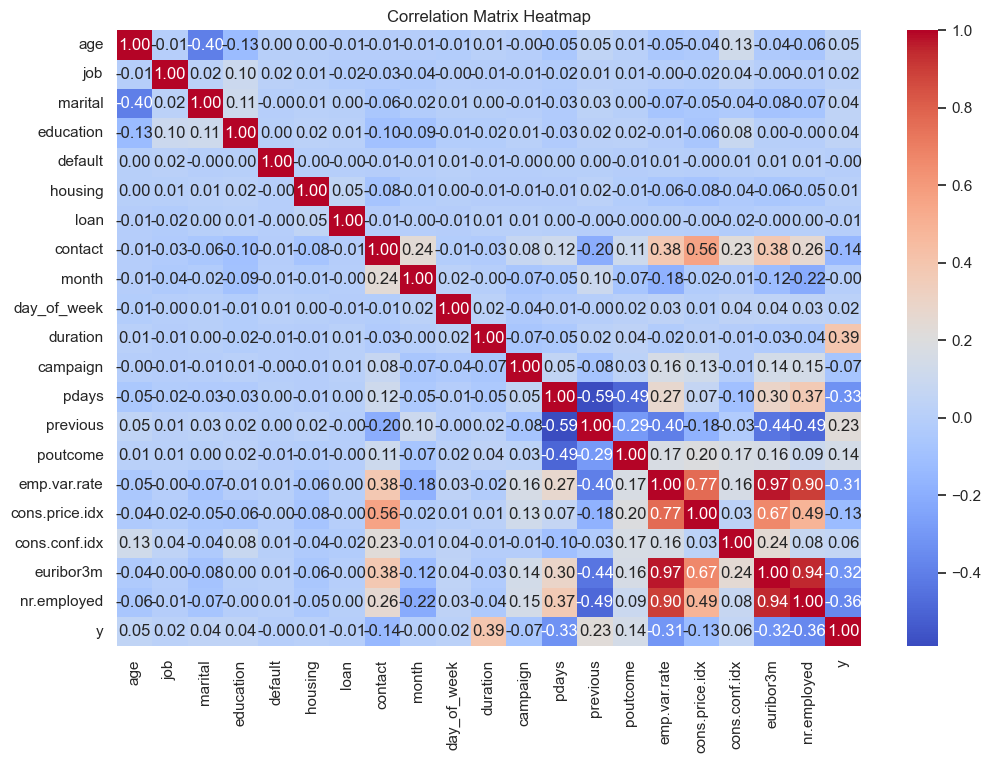

```python
plt.figure(figsize=(12, 8))
sns.heatmap(bank_encoded.corr(), annot=True, cmap='coolwarm', fmt=".2f")
plt.title("Correlation Matrix Heatmap")
plt.show()
```

To reduce the dimensionality and redundancy of our data lets drop any low correlation features

```python
correlations = bank_encoded.corr()['y'].drop('y')

low_corr_threshold = 0.2
low_corr_features = correlations[correlations.abs() < low_corr_threshold].index.tolist()

print("Dropping low-correlation features (|corr| < 0.2):")
print(low_corr_features)

print("\n")

bank_filtered = bank_encoded.drop(columns=low_corr_features)
print("Remaining features:", bank_filtered.columns.tolist())
```

```
Dropping low-correlation features (|corr| < 0.2):
['age', 'job', 'marital', 'education', 'default', 'housing', 'loan', 'contact', 'month', 'day_of_week', 'campaign', 'poutcome', 'cons.price.idx', 'cons.conf.idx']


Remaining features: ['duration', 'pdays', 'previous', 'emp.var.rate', 'euribor3m', 'nr.employed', 'y']
```

Now replot the filtered data in a correlation matric

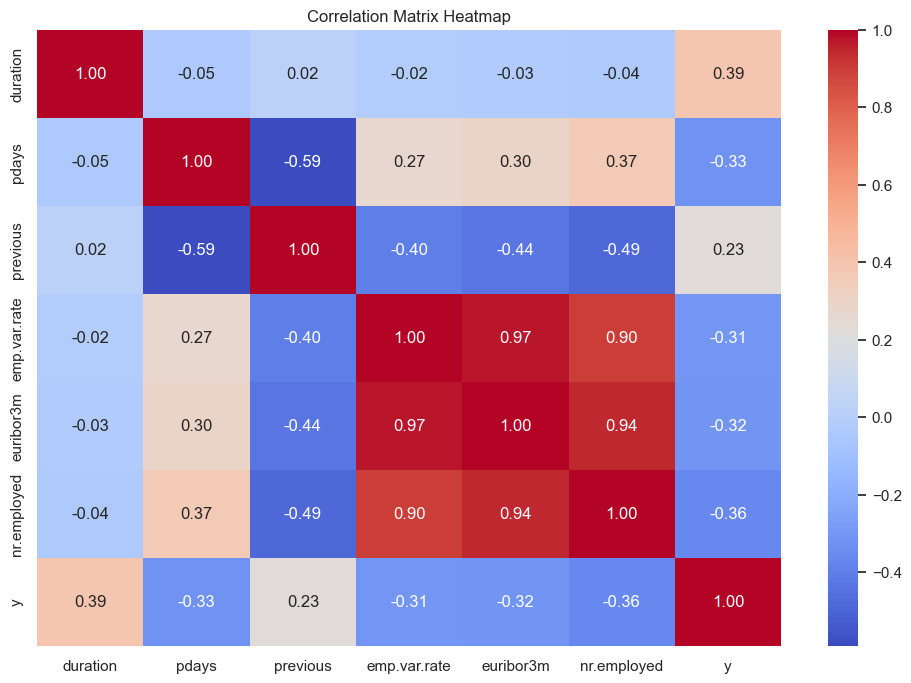

```python
plt.figure(figsize=(12, 8))
sns.heatmap(bank_filtered.corr(), annot=True, cmap='coolwarm', fmt=".2f")
plt.title("Correlation Matrix Heatmap")
plt.show()
```

```python
bank_encoded = bank_filtered.copy()
```

## Research Question:

**Can we predict with a high degree of accuracy which individuals subscribed to a term deposite?**

The bank-additional-names.txt file states about duration: `this attribute highly affects the output target (e.g., if duration=0 then y="no"). Yet, the duration is not known before a call is performed. Also, after the end of the call y is obviously known. Thus, this input should only be included for benchmark purposes and should be discarded if the intention is to have a realistic predictive model.`

This means that if we are trying to predict y, duration will cause leakage.

Lets drop duration from the dataset.

```python
bank_encoded = bank_encoded.drop(columns=['duration'])
```

Before we begin with building any models lets establish a baseline.

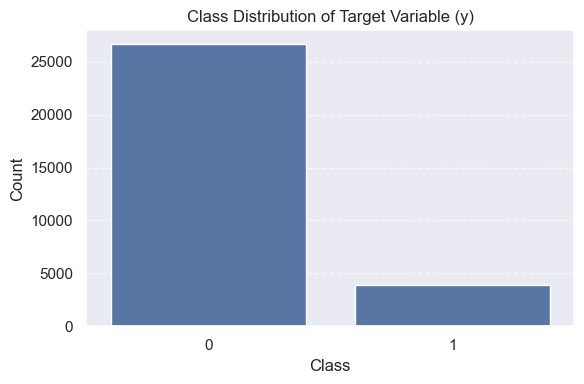

```python
plt.figure(figsize=(6, 4))
sns.countplot(x=bank_encoded['y'])
plt.title("Class Distribution of Target Variable (y)")
plt.xlabel("Class")
plt.ylabel("Count")
plt.grid(axis='y', linestyle='--', alpha=0.7)
plt.tight_layout()
plt.show()
```

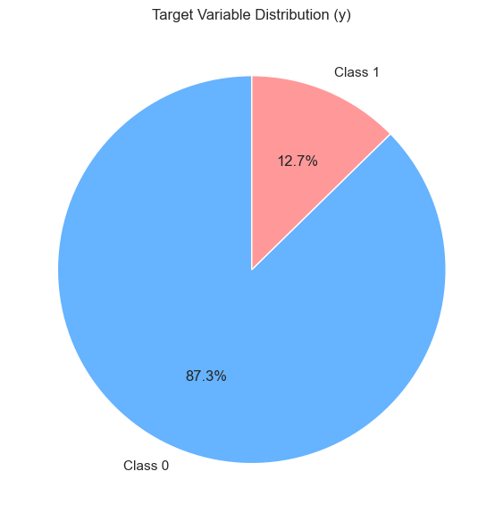

```python
plt.figure(figsize=(6, 6))
counts = bank_encoded['y'].value_counts()
labels = ['Class 0', 'Class 1']
plt.pie(counts, labels=labels, autopct='%1.1f%%', startangle=90, colors=['#66b3ff','#ff9999'])
plt.title("Target Variable Distribution (y)")
plt.tight_layout()
plt.show()
```

```python
bank_encoded['y'].value_counts()
```

```
y
0    26629
1     3859
Name: count, dtype: int64
```

```python
y = bank_encoded['y']

baseline_0_acc = (y == 0).mean()
baseline_1_acc = (y == 1).mean()

print(f"Baseline Accuracy (always predict 0): {baseline_0_acc:.4%}")
print(f"Baseline Accuracy (always predict 1): {baseline_1_acc:.4%}")
```

```
Baseline Accuracy (always predict 0): 87.3426%
Baseline Accuracy (always predict 1): 12.6574%
```

Now lets seperate our testing and training data.

```python
feat_cols = bank_encoded.drop(columns=['y'])
target_col = bank_encoded['y']
```

```python
feat_cols
```

|  | pdays | previous | emp.var.rate | euribor3m | nr.employed |
| --- | --- | --- | --- | --- | --- |
| 0 | 999 | 0 | 1.1 | 4.857 | 5191.0 |
| 1 | 999 | 0 | 1.1 | 4.857 | 5191.0 |
| 2 | 999 | 0 | 1.1 | 4.857 | 5191.0 |
| 3 | 999 | 0 | 1.1 | 4.857 | 5191.0 |
| 4 | 999 | 0 | 1.1 | 4.857 | 5191.0 |
| ... | ... | ... | ... | ... | ... |
| 30483 | 999 | 0 | -1.1 | 1.028 | 4963.6 |
| 30484 | 999 | 0 | -1.1 | 1.028 | 4963.6 |
| 30485 | 999 | 0 | -1.1 | 1.028 | 4963.6 |
| 30486 | 999 | 0 | -1.1 | 1.028 | 4963.6 |
| 30487 | 999 | 1 | -1.1 | 1.028 | 4963.6 |

30488 rows × 5 columns

```python
target_col
```

```
0        0
1        0
2        0
3        0
4        0
        ..
30483    1
30484    0
30485    0
30486    1
30487    0
Name: y, Length: 30488, dtype: int64
```

```python
X_train_raw, X_test_raw, y_train_raw, y_test_raw = train_test_split(feat_cols, target_col, test_size=0.3, random_state=42)
```

Since this is a binary classification problem lets use the KNeighborsClassfier model.

```python
model = KNeighborsClassifier(n_neighbors=2, n_jobs=-1)
model.fit(X_train_raw, y_train_raw)
preds = model.predict(X_test_raw)

train_acc = model.score(X_train_raw, y_train_raw)
test_acc = accuracy_score(y_test_raw, preds)

print("\nClassification Report:")
print(classification_report(y_test_raw, preds, digits=4))
```

```
Classification Report:
              precision    recall  f1-score   support

           0     0.8876    0.9831    0.9329      7974
           1     0.5714    0.1535    0.2419      1173

    accuracy                         0.8767      9147
   macro avg     0.7295    0.5683    0.5874      9147
weighted avg     0.8470    0.8767    0.8443      9147
```

Our base model with k=2 resulted in a precisiion score of `0.8876` for 0 labels and a precisiion score of `0.5714` for 1 labels.

The weighted average precision for this model is `84.7%`.

Lets optimize our classifier by trying different k values.

```python
scores = []
for k in range(2, 20):
    print(f'Evaluating {k} neighbors')
    model = KNeighborsClassifier(n_neighbors=k, n_jobs=-1)
    model.fit(X_train_raw, y_train_raw)
    preds = model.predict(X_test_raw)
    acc = accuracy_score(y_test_raw, preds)
    scores.append(acc)
```

```
Evaluating 2 neighbors
Evaluating 3 neighbors
Evaluating 4 neighbors
Evaluating 5 neighbors
Evaluating 6 neighbors
Evaluating 7 neighbors
Evaluating 8 neighbors
Evaluating 9 neighbors
Evaluating 10 neighbors
Evaluating 11 neighbors
Evaluating 12 neighbors
Evaluating 13 neighbors
Evaluating 14 neighbors
Evaluating 15 neighbors
Evaluating 16 neighbors
Evaluating 17 neighbors
Evaluating 18 neighbors
Evaluating 19 neighbors
```

Now plot the results

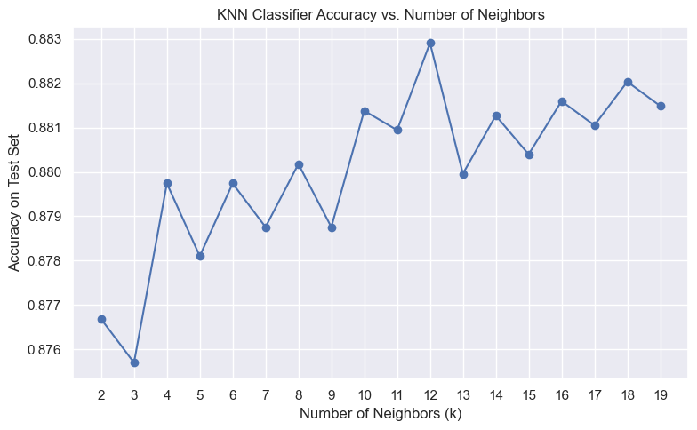

```python
plt.figure(figsize=(8, 5))
plt.plot(range(2, 20), scores, marker='o')
plt.title("KNN Classifier Accuracy vs. Number of Neighbors")
plt.xlabel("Number of Neighbors (k)")
plt.ylabel("Accuracy on Test Set")
plt.xticks(ticks=range(2, 20))
plt.grid(True)
plt.tight_layout()
plt.show()
```

The model with the highest accuracy appears to use a k value of 12. Lets make a new model and check to see if the results are improved.

```
Classification Report:
              precision    recall  f1-score   support

           0     0.9020    0.9694    0.9345      7974
           1     0.5771    0.2839    0.3806      1173

    accuracy                         0.8815      9147
   macro avg     0.7396    0.6266    0.6575      9147
weighted avg     0.8603    0.8815    0.8634      9147
```

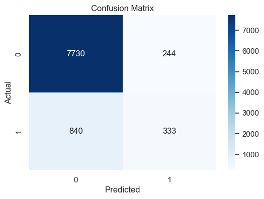

```python
selected_k = 12
model_2 = KNeighborsClassifier(n_neighbors=selected_k, n_jobs=-1)
model_2.fit(X_train_raw, y_train_raw)

train_acc = model.score(X_train_raw, y_train_raw)
test_acc = accuracy_score(y_test_raw, preds)

print("\nClassification Report:")
print(classification_report(y_test_raw, preds, digits=4))

cm = confusion_matrix(y_test_raw, preds)

plt.figure(figsize=(6, 4))
sns.heatmap(cm, annot=True, fmt='d', cmap='Blues', xticklabels=[0,1], yticklabels=[0,1])
plt.xlabel('Predicted')
plt.ylabel('Actual')
plt.title('Confusion Matrix')
plt.show()
```

Lets attempt to improve this mdoel further by normalizing the data before training.

```
Classification Report:
              precision    recall  f1-score   support

           0     0.8992    0.9743    0.9352      7974
           1     0.5957    0.2575    0.3595      1173

    accuracy                         0.8824      9147
   macro avg     0.7474    0.6159    0.6474      9147
weighted avg     0.8603    0.8824    0.8614      9147
```

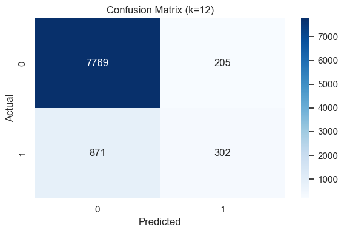

```python
scaler = StandardScaler()
X_train_scaled = scaler.fit_transform(X_train_raw)
X_test_scaled = scaler.transform(X_test_raw)

model = KNeighborsClassifier(n_neighbors=12, n_jobs=-1)
model.fit(X_train_scaled, y_train_raw)
preds = model.predict(X_test_scaled)
train_acc = model.score(X_train_scaled, y_train_raw)
test_acc = accuracy_score(y_test_raw, preds)

print("\nClassification Report:")
print(classification_report(y_test_raw, preds, digits=4))


cm = confusion_matrix(y_test_raw, preds)

plt.figure(figsize=(6, 4))
sns.heatmap(cm, annot=True, fmt='d', cmap='Blues', xticklabels=[0, 1], yticklabels=[0, 1])
plt.xlabel('Predicted')
plt.ylabel('Actual')
plt.title(f'Confusion Matrix (k=12)')
plt.tight_layout()
plt.show()
```

Training the model with normalized data reduced the precision score slightly for the 0 label at `0.8992` but improved the precision score for the 1 label to `0.5957`.

This is not a large change form the pevious model, as the weighted average precision is stilla round `86%`

Since this model appears to have performed the best lets save it to a file.

```python
joblib.dump(model, f"./assign_wk5/generated_data/knn_best_k12.joblib")
print(f"Model saved as knn_best_k12.joblib")
```

```
Model saved as knn_best_k12.joblib
```

To take this a step further, lets test our trained model on data it hasn't seen before.

Since we are only using 5 features from the original dataset we might be able to use the unclean data we set aside eariler that contains `unknown` data values.

Lets load this unclean data, clean it, and identify whether we can use it to test our model further.

```python
df = pd.read_csv('./assign_wk5/generated_data/bank_with_unknown_values.csv')

required_features = ['pdays', 'previous', 'emp.var.rate', 'euribor3m', 'nr.employed', 'y']
raw_df = df[required_features].copy()

clean_df = raw_df[~raw_df.eq('unknown').any(axis=1)]


label_encoder = LabelEncoder()
for col in clean_df.select_dtypes(include=['object']).columns:
    clean_df[col] = label_encoder.fit_transform(clean_df[col])


selected_features = ['pdays', 'previous', 'emp.var.rate', 'euribor3m', 'nr.employed']
X_clean = clean_df[selected_features]

y_clean = clean_df['y']

print(f"Number of testable rows: {len(X_clean)} out of {len(clean_df)}")
```

```
Number of testable rows: 10700 out of 10700
```

Fortunately, there are 0 `unknown` values located in the 5 features we selected to use for this model. We can use every row!

Lets normalize the now cleaned data, load the pre-trained model, and test it's accuracy since it hasn't 'seen' any of this data yet.

```
Classification Report:
              precision    recall  f1-score   support

           0     0.9357    0.9944    0.9641      9919
           1     0.6478    0.1319    0.2191       781

    accuracy                         0.9314     10700
   macro avg     0.7917    0.5631    0.5916     10700
weighted avg     0.9147    0.9314    0.9097     10700
```

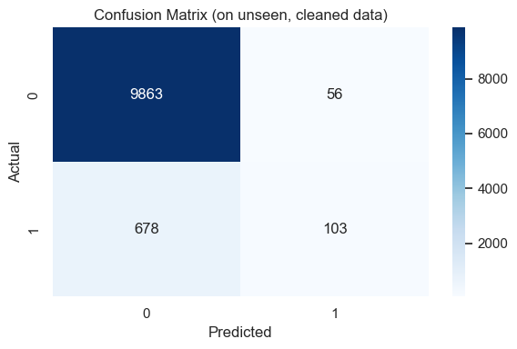

```python
scaler = StandardScaler()
X_scaled = scaler.fit_transform(X_clean)

pre_trained_model = joblib.load('./assign_wk5/generated_data/knn_best_k12.joblib')

preds = pre_trained_model.predict(X_scaled)

print("\nClassification Report:")
print(classification_report(y_clean, preds, digits=4))

cm = confusion_matrix(y_clean, preds)

plt.figure(figsize=(6, 4))
sns.heatmap(cm, annot=True, fmt='d', cmap='Blues', xticklabels=[0, 1], yticklabels=[0, 1])
plt.xlabel('Predicted')
plt.ylabel('Actual')
plt.title('Confusion Matrix (on unseen, cleaned data)')
plt.tight_layout()
plt.show()
```

## SUMMARY

Initially, the model scored better than the baseline but improvements were needed. I tested multiple k values and identified that a `k-value of 12` perfromed the best. Then we normalized the data which resulted in minimal categorical improvements, but no real gain in the overall wieghted precision score.

**Future opportunities:**

In the future, I would impute the unknown data values by training classification models from the available data. Then, I would further optimize the term deposit predictor by comparing different classification model types, different normalization techniques, different feature selection processes, and different model dimensions. While this predictor model is successful, I would be surprised if in such a short amount of experimentation I stumbled onto the `best` model available.